# Bellabeat Case Study

Mohamed Shaeldin

31/01/2022

## INTRODUCTION

This case study was made as a final project for the Google Data Analytics Certificate. by analyzing FitBit Fitness Tracker Data to make useful insights for Bellabeat.

### following the data life cycle steps in this case study :

- **ASK**
- **Prepare**
- **Process**
- **Analyze**
- **Share**
- **Act**

## 1) ASK

### Background

Bellabeat is a high-tech manufacturer of beautifully-designed health-focused smart products for women since 2013.Bellabeat has grown rapidly and quickly positioned itself as a tech-driven wellness company for females.

The co-founder and Chief Creative Officer, Urška Sršen is confident that an analysis of non-Bellebeat consumer data (ie. FitBit fitness tracker usage data) would reveal more opportunities for growth.

### Business Task:

- Analyze FitBit fitness tracker data to gain insights into how consumers are using the FitBit app.
- discover trends for Bellabeat marketing strategy.

### Objectives:

1. What are some trends in smart device usage?
2. How could these trends apply to Bellabeat customers?
3. How could these trends help influence Bellabeat marketing strategy?

### key stakeholders:

1. Urška Sršen (Bellabeat’s cofounder and Chief Creative Officer).
2. Sando Mur (Mathematician and Bellabeat’s cofounder).
3. Bellabeat marketing analytics team.

## 2) Prepare

### Checking the data credibility with ROCCC :

(**R**eliable, **O**riginal, **C**omprehensive, **C**urrent, and **C**ited)

Classification by : (Low -> Medium -> High)

[output not shown]

#### Final assessment of the data source:

the dataset is considered bad quality data and not recommended for analysis and to produce business recommendations based on this data.

### Tool:

We are using **Rstudio** for data cleaning, transformation and visualization.

## 3) Process

The Data Must be cleaned for analysis.

### Cleaning Steps:

- Install R packages and Observe the data.
- Remove duplicate values
- Remove empty rows

Installing cleaning packages, Loading libraries for processing and analyzing data

```r
library(tidyverse)
library(readxl)
library(lubridate)
```

Importing Data

```r
dailyActivity_merged <- read_csv("Fitabase Data 4.12.16-5.12.16/dailyActivity_merged.csv")
dailyCalories_merged <- read_csv("Fitabase Data 4.12.16-5.12.16/dailyCalories_merged.csv")
dailyIntensities_merged <- read_csv("Fitabase Data 4.12.16-5.12.16/dailyIntensities_merged.csv")
sleepDay_merged <- read_csv("Fitabase Data 4.12.16-5.12.16/sleepDay_merged.csv")
weightLogInfo_merged <- read_csv("Fitabase Data 4.12.16-5.12.16/weightLogInfo_merged.csv")
```

### Over viewing and Getting Familiar with datasets:

```r
daily_activity <- dailyActivity_merged
daily_calories <- dailyCalories_merged
daily_intensities <- dailyIntensities_merged
sleep_day <- sleepDay_merged
weight_log <- weightLogInfo_merged

head(daily_activity)
```

```
## # A tibble: 6 x 15
##        Id ActivityDate TotalSteps TotalDistance TrackerDistance LoggedActivitie~
##     <dbl> <chr>             <dbl>         <dbl>           <dbl>            <dbl>
## 1  1.50e9 4/12/2016         13162          8.5             8.5                 0
## 2  1.50e9 4/13/2016         10735          6.97            6.97                0
## 3  1.50e9 4/14/2016         10460          6.74            6.74                0
## 4  1.50e9 4/15/2016          9762          6.28            6.28                0
## 5  1.50e9 4/16/2016         12669          8.16            8.16                0
## 6  1.50e9 4/17/2016          9705          6.48            6.48                0
## # ... with 9 more variables: VeryActiveDistance <dbl>,
## #   ModeratelyActiveDistance <dbl>, LightActiveDistance <dbl>,
## #   SedentaryActiveDistance <dbl>, VeryActiveMinutes <dbl>,
## #   FairlyActiveMinutes <dbl>, LightlyActiveMinutes <dbl>,
## #   SedentaryMinutes <dbl>, Calories <dbl>
```

```r
colnames(daily_activity)
```

```
##  [1] "Id"                       "ActivityDate"
##  [3] "TotalSteps"               "TotalDistance"
##  [5] "TrackerDistance"          "LoggedActivitiesDistance"
##  [7] "VeryActiveDistance"       "ModeratelyActiveDistance"
##  [9] "LightActiveDistance"      "SedentaryActiveDistance"
## [11] "VeryActiveMinutes"        "FairlyActiveMinutes"
## [13] "LightlyActiveMinutes"     "SedentaryMinutes"
## [15] "Calories"
```

```r
glimpse(daily_activity)
```

```
## Rows: 940
## Columns: 15
## $ Id                       <dbl> 1503960366, 1503960366, 1503960366, 150396036~
## $ ActivityDate             <chr> "4/12/2016", "4/13/2016", "4/14/2016", "4/15/~
## $ TotalSteps               <dbl> 13162, 10735, 10460, 9762, 12669, 9705, 13019~
## $ TotalDistance            <dbl> 8.50, 6.97, 6.74, 6.28, 8.16, 6.48, 8.59, 9.8~
## $ TrackerDistance          <dbl> 8.50, 6.97, 6.74, 6.28, 8.16, 6.48, 8.59, 9.8~
## $ LoggedActivitiesDistance <dbl> 0, 0, 0, 0, 0, 0, 0, 0, 0, 0, 0, 0, 0, 0, 0, ~
## $ VeryActiveDistance       <dbl> 1.88, 1.57, 2.44, 2.14, 2.71, 3.19, 3.25, 3.5~
## $ ModeratelyActiveDistance <dbl> 0.55, 0.69, 0.40, 1.26, 0.41, 0.78, 0.64, 1.3~
## $ LightActiveDistance      <dbl> 6.06, 4.71, 3.91, 2.83, 5.04, 2.51, 4.71, 5.0~
## $ SedentaryActiveDistance  <dbl> 0, 0, 0, 0, 0, 0, 0, 0, 0, 0, 0, 0, 0, 0, 0, ~
## $ VeryActiveMinutes        <dbl> 25, 21, 30, 29, 36, 38, 42, 50, 28, 19, 66, 4~
## $ FairlyActiveMinutes      <dbl> 13, 19, 11, 34, 10, 20, 16, 31, 12, 8, 27, 21~
## $ LightlyActiveMinutes     <dbl> 328, 217, 181, 209, 221, 164, 233, 264, 205, ~
## $ SedentaryMinutes         <dbl> 728, 776, 1218, 726, 773, 539, 1149, 775, 818~
## $ Calories                 <dbl> 1985, 1797, 1776, 1745, 1863, 1728, 1921, 203~
```

```r
head(daily_calories)
```

```
## # A tibble: 6 x 3
##           Id ActivityDay Calories
##        <dbl> <chr>          <dbl>
## 1 1503960366 4/12/2016       1985
## 2 1503960366 4/13/2016       1797
## 3 1503960366 4/14/2016       1776
## 4 1503960366 4/15/2016       1745
## 5 1503960366 4/16/2016       1863
## 6 1503960366 4/17/2016       1728
```

```r
colnames(daily_calories)
```

```
## [1] "Id"          "ActivityDay" "Calories"
```

```r
glimpse(daily_calories)
```

```
## Rows: 940
## Columns: 3
## $ Id          <dbl> 1503960366, 1503960366, 1503960366, 1503960366, 1503960366~
## $ ActivityDay <chr> "4/12/2016", "4/13/2016", "4/14/2016", "4/15/2016", "4/16/~
## $ Calories    <dbl> 1985, 1797, 1776, 1745, 1863, 1728, 1921, 2035, 1786, 1775~
```

```r
head(sleep_day)
```

```
## # A tibble: 6 x 5
##           Id SleepDay          TotalSleepRecor~ TotalMinutesAsle~ TotalTimeInBed
##        <dbl> <chr>                        <dbl>             <dbl>          <dbl>
## 1 1503960366 4/12/2016 12:00:~                1               327            346
## 2 1503960366 4/13/2016 12:00:~                2               384            407
## 3 1503960366 4/15/2016 12:00:~                1               412            442
## 4 1503960366 4/16/2016 12:00:~                2               340            367
## 5 1503960366 4/17/2016 12:00:~                1               700            712
## 6 1503960366 4/19/2016 12:00:~                1               304            320
```

```r
colnames(sleep_day)
```

```
## [1] "Id"                 "SleepDay"           "TotalSleepRecords"
## [4] "TotalMinutesAsleep" "TotalTimeInBed"
```

```r
glimpse(sleep_day)
```

```
## Rows: 413
## Columns: 5
## $ Id                 <dbl> 1503960366, 1503960366, 1503960366, 1503960366, 150~
## $ SleepDay           <chr> "4/12/2016 12:00:00 AM", "4/13/2016 12:00:00 AM", "~
## $ TotalSleepRecords  <dbl> 1, 2, 1, 2, 1, 1, 1, 1, 1, 1, 1, 1, 1, 1, 1, 1, 1, ~
## $ TotalMinutesAsleep <dbl> 327, 384, 412, 340, 700, 304, 360, 325, 361, 430, 2~
## $ TotalTimeInBed     <dbl> 346, 407, 442, 367, 712, 320, 377, 364, 384, 449, 3~
```

```r
head(weight_log)
```

```
## # A tibble: 6 x 8
##           Id Date      WeightKg WeightPounds   Fat   BMI IsManualReport    LogId
##        <dbl> <chr>        <dbl>        <dbl> <dbl> <dbl> <lgl>             <dbl>
## 1 1503960366 5/2/2016~     52.6         116.    22  22.6 TRUE            1.46e12
## 2 1503960366 5/3/2016~     52.6         116.    NA  22.6 TRUE            1.46e12
## 3 1927972279 4/13/201~    134.          294.    NA  47.5 FALSE           1.46e12
## 4 2873212765 4/21/201~     56.7         125.    NA  21.5 TRUE            1.46e12
## 5 2873212765 5/12/201~     57.3         126.    NA  21.7 TRUE            1.46e12
## 6 4319703577 4/17/201~     72.4         160.    25  27.5 TRUE            1.46e12
```

```r
colnames(weight_log)
```

```
## [1] "Id"             "Date"           "WeightKg"       "WeightPounds"
## [5] "Fat"            "BMI"            "IsManualReport" "LogId"
```

```r
glimpse(weight_log)
```

```
## Rows: 67
## Columns: 8
## $ Id             <dbl> 1503960366, 1503960366, 1927972279, 2873212765, 2873212~
## $ Date           <chr> "5/2/2016 11:59:59 PM", "5/3/2016 11:59:59 PM", "4/13/2~
## $ WeightKg       <dbl> 52.6, 52.6, 133.5, 56.7, 57.3, 72.4, 72.3, 69.7, 70.3, ~
## $ WeightPounds   <dbl> 115.9631, 115.9631, 294.3171, 125.0021, 126.3249, 159.6~
## $ Fat            <dbl> 22, NA, NA, NA, NA, 25, NA, NA, NA, NA, NA, NA, NA, NA,~
## $ BMI            <dbl> 22.65, 22.65, 47.54, 21.45, 21.69, 27.45, 27.38, 27.25,~
## $ IsManualReport <lgl> TRUE, TRUE, FALSE, TRUE, TRUE, TRUE, TRUE, TRUE, TRUE, ~
## $ LogId          <dbl> 1.462234e+12, 1.462320e+12, 1.460510e+12, 1.461283e+12,~
```

```r
head(daily_intensities)
```

```
## # A tibble: 6 x 10
##           Id ActivityDay SedentaryMinutes LightlyActiveMinutes FairlyActiveMinu~
##        <dbl> <chr>                  <dbl>                <dbl>             <dbl>
## 1 1503960366 4/12/2016                728                  328                13
## 2 1503960366 4/13/2016                776                  217                19
## 3 1503960366 4/14/2016               1218                  181                11
## 4 1503960366 4/15/2016                726                  209                34
## 5 1503960366 4/16/2016                773                  221                10
## 6 1503960366 4/17/2016                539                  164                20
## # ... with 5 more variables: VeryActiveMinutes <dbl>,
## #   SedentaryActiveDistance <dbl>, LightActiveDistance <dbl>,
## #   ModeratelyActiveDistance <dbl>, VeryActiveDistance <dbl>
```

```r
colnames(daily_intensities)
```

```
##  [1] "Id"                       "ActivityDay"
##  [3] "SedentaryMinutes"         "LightlyActiveMinutes"
##  [5] "FairlyActiveMinutes"      "VeryActiveMinutes"
##  [7] "SedentaryActiveDistance"  "LightActiveDistance"
##  [9] "ModeratelyActiveDistance" "VeryActiveDistance"
```

```r
glimpse(daily_intensities)
```

```
## Rows: 940
## Columns: 10
## $ Id                       <dbl> 1503960366, 1503960366, 1503960366, 150396036~
## $ ActivityDay              <chr> "4/12/2016", "4/13/2016", "4/14/2016", "4/15/~
## $ SedentaryMinutes         <dbl> 728, 776, 1218, 726, 773, 539, 1149, 775, 818~
## $ LightlyActiveMinutes     <dbl> 328, 217, 181, 209, 221, 164, 233, 264, 205, ~
## $ FairlyActiveMinutes      <dbl> 13, 19, 11, 34, 10, 20, 16, 31, 12, 8, 27, 21~
## $ VeryActiveMinutes        <dbl> 25, 21, 30, 29, 36, 38, 42, 50, 28, 19, 66, 4~
## $ SedentaryActiveDistance  <dbl> 0, 0, 0, 0, 0, 0, 0, 0, 0, 0, 0, 0, 0, 0, 0, ~
## $ LightActiveDistance      <dbl> 6.06, 4.71, 3.91, 2.83, 5.04, 2.51, 4.71, 5.0~
## $ ModeratelyActiveDistance <dbl> 0.55, 0.69, 0.40, 1.26, 0.41, 0.78, 0.64, 1.3~
## $ VeryActiveDistance       <dbl> 1.88, 1.57, 2.44, 2.14, 2.71, 3.19, 3.25, 3.5~
```

### Data cleaning

#### A)Removing duplicates

Id and activity date should be unique (0 observations removed)

```r
daily_activity <- daily_activity %>%
  distinct(Id, ActivityDate, .keep_all = TRUE)
```

Id and activity date should be unique (3 observations removed)

```r
sleep_day <- sleep_day %>%
  distinct(Id, SleepDay, .keep_all = TRUE)
```

Id and Date should be unique (0 observations removed)

```r
weight_log <- weight_log %>%
  distinct(Id, Date, .keep_all = TRUE)
```

#### B) Checking for NA values and removing if any exist

```r
which(!complete.cases(daily_activity))
```

```
## integer(0)
```

```r
which(!complete.cases(sleep_day))
```

```
## integer(0)
```

```r
which(!complete.cases(daily_intensities))
```

```
## integer(0)
```

```r
which(!complete.cases(weight_log))
```

```
##  [1]  2  3  4  5  7  8  9 10 11 12 13 14 15 16 17 18 19 20 21 22 23 24 25 26 27
## [26] 28 29 30 31 32 33 34 35 36 37 38 39 40 41 42 43 44 45 46 47 48 49 50 51 52
## [51] 53 54 55 56 57 58 59 60 61 62 63 64 65 66 67
```

## 4) Analyze

- daily_activity.
- weight_log.
- daily_intensities.
- sleep_day.

#### Initial observations:

- They all contain ID column.
- daily_activity, daily_intensities and daily_calories has same Rows Number(940).
- daily_activity contain all daily_calories attribute and daily_ intensities.

### A) daily activity Trends:

```r
daily_activity_on <- daily_activity[daily_activity$TotalSteps > 700, ]
```

- Then we group by Id, and finding the mean for each activity

```r
daily_activity_users <- daily_activity_on %>%
  group_by(Id) %>%
  summarise(VeryActiveMinutes_av = mean(VeryActiveMinutes),
            FairlyActiveMinutes_av = mean(FairlyActiveMinutes),
            LightlyActiveMinutes_av = mean(LightlyActiveMinutes),
            SedentaryMinutes_av = mean(SedentaryMinutes),
            Calories_av = mean(Calories))

daily_activity_users <- daily_activity_users %>%
  mutate(very_fairly_active_avg = VeryActiveMinutes_av + FairlyActiveMinutes_av)
```

- Creating a variable for active and non-active users

```r
daily_activity_users <- daily_activity_users %>%
  mutate(active = ifelse(very_fairly_active_avg > 60, "active", "non-active"))
```

#### Create a bar chart to visualize the Result :

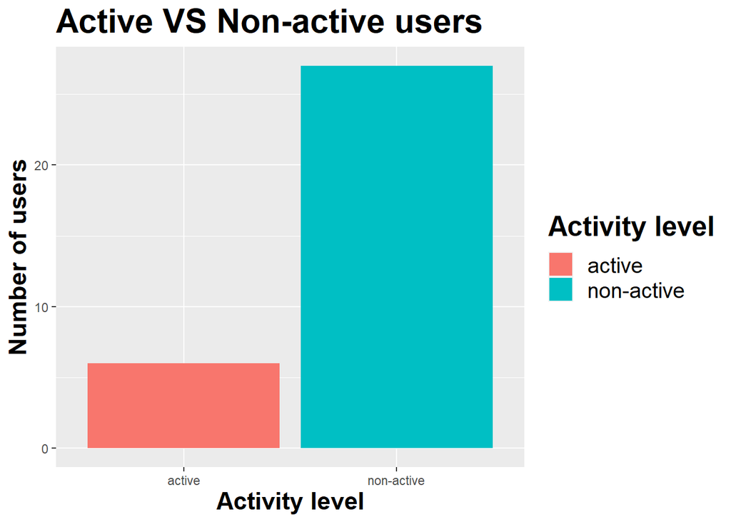

```r
ggplot(data = daily_activity_users)+
  geom_bar(mapping = aes(x = active,  fill = active))+
  labs(title = "Active VS Non-active users", x = "Activity level", y = "Number of users")+
  theme(title = element_text(size=19, face="bold"),
        axis.title=element_text(size=17,face="bold"),
        legend.text=element_text(size=15))+
  guides(fill=guide_legend(title="Activity level"))
```

### **B) daily_activity VS daily_calories & daily_intensities**

- By creating temp data frame named it daily_activity_Temp

```r
daily_activity_Temp1 <- daily_activity %>%
  select(Id, ActivityDate, Calories)

head(daily_activity_Temp1)
```

```
## # A tibble: 6 x 3
##           Id ActivityDate Calories
##        <dbl> <chr>           <dbl>
## 1 1503960366 4/12/2016        1985
## 2 1503960366 4/13/2016        1797
## 3 1503960366 4/14/2016        1776
## 4 1503960366 4/15/2016        1745
## 5 1503960366 4/16/2016        1863
## 6 1503960366 4/17/2016        1728
```

```r
glimpse(daily_activity_Temp1)
```

```
## Rows: 940
## Columns: 3
## $ Id           <dbl> 1503960366, 1503960366, 1503960366, 1503960366, 150396036~
## $ ActivityDate <chr> "4/12/2016", "4/13/2016", "4/14/2016", "4/15/2016", "4/16~
## $ Calories     <dbl> 1985, 1797, 1776, 1745, 1863, 1728, 1921, 2035, 1786, 177~
```

we check if the two data frames of daily_activity_Temp1 and daily_calories are same.

**first we**:

install the (sqldf) package for ruining SQL statements on R data frames, optimized for convenience.

```r
library(sqldf)
sql_check1 <- sqldf('SELECT * FROM daily_activity_Temp1 INTERSECT SELECT * FROM daily_calories')
head(sql_check1)
```

```
##           Id ActivityDate Calories
## 1 1503960366    4/12/2016     1985
## 2 1503960366    4/13/2016     1797
## 3 1503960366    4/14/2016     1776
## 4 1503960366    4/15/2016     1745
## 5 1503960366    4/16/2016     1863
## 6 1503960366    4/17/2016     1728
```

```r
glimpse(sql_check1)
```

```
## Rows: 940
## Columns: 3
## $ Id           <dbl> 1503960366, 1503960366, 1503960366, 1503960366, 150396036~
## $ ActivityDate <chr> "4/12/2016", "4/13/2016", "4/14/2016", "4/15/2016", "4/16~
## $ Calories     <dbl> 1985, 1797, 1776, 1745, 1863, 1728, 1921, 2035, 1786, 177~
```

#### That leaves us with (3) data frames:

- daily_activity.
- sleep_day.
- weight_log.

let check the Number of Id’s in daily_activity and sleep_day

```r
n_distinct(daily_activity$Id)
```

```
## [1] 33
```

```r
n_distinct(sleep_day$Id)
```

```
## [1] 24
```

```r
n_distinct(weight_log$Id)
```

```
## [1] 8
```

let check the number of observation in each

```r
nrow(daily_activity)
```

```
## [1] 940
```

```r
nrow(sleep_day)
```

```
## [1] 410
```

```r
nrow(weight_log)
```

```
## [1] 67
```

### Statistical Calculation summery

#### A) daily_activity

```r
daily_activity %>%
  select(TotalSteps, TotalDistance, VeryActiveMinutes, SedentaryMinutes, Calories) %>%
  summary()
```

```
##    TotalSteps    TotalDistance    VeryActiveMinutes SedentaryMinutes
##  Min.   :    0   Min.   : 0.000   Min.   :  0.00    Min.   :   0.0
##  1st Qu.: 3790   1st Qu.: 2.620   1st Qu.:  0.00    1st Qu.: 729.8
##  Median : 7406   Median : 5.245   Median :  4.00    Median :1057.5
##  Mean   : 7638   Mean   : 5.490   Mean   : 21.16    Mean   : 991.2
##  3rd Qu.:10727   3rd Qu.: 7.713   3rd Qu.: 32.00    3rd Qu.:1229.5
##  Max.   :36019   Max.   :28.030   Max.   :210.00    Max.   :1440.0
##     Calories
##  Min.   :   0
##  1st Qu.:1828
##  Median :2134
##  Mean   :2304
##  3rd Qu.:2793
##  Max.   :4900
```

#### B) sleep_day

```r
sleep_day %>%
  select(TotalSleepRecords, TotalMinutesAsleep, TotalTimeInBed) %>%
  summary()
```

```
##  TotalSleepRecords TotalMinutesAsleep TotalTimeInBed
##  Min.   :1.00      Min.   : 58.0      Min.   : 61.0
##  1st Qu.:1.00      1st Qu.:361.0      1st Qu.:403.8
##  Median :1.00      Median :432.5      Median :463.0
##  Mean   :1.12      Mean   :419.2      Mean   :458.5
##  3rd Qu.:1.00      3rd Qu.:490.0      3rd Qu.:526.0
##  Max.   :3.00      Max.   :796.0      Max.   :961.0
```

#### C) weight_log

```r
weight_log %>%
  select(WeightKg,BMI) %>%
  summary()
```

```
##     WeightKg           BMI
##  Min.   : 52.60   Min.   :21.45
##  1st Qu.: 61.40   1st Qu.:23.96
##  Median : 62.50   Median :24.39
##  Mean   : 72.04   Mean   :25.19
##  3rd Qu.: 85.05   3rd Qu.:25.56
##  Max.   :133.50   Max.   :47.54
```

## 5) Share

## few explorations

### Total steps VS sedentary minutes

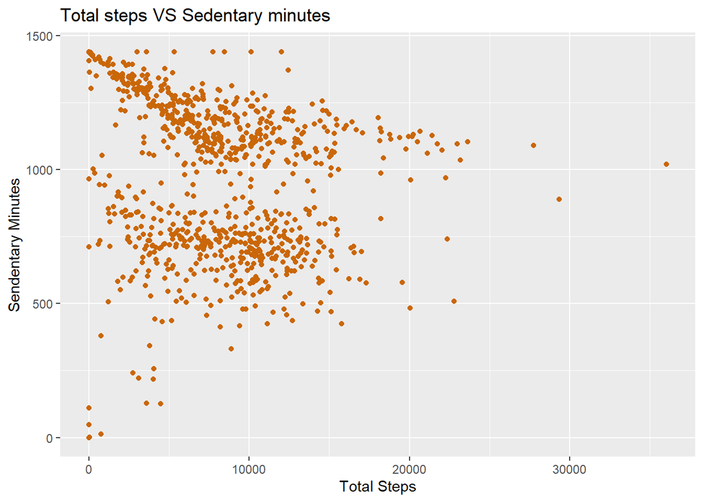

```r
ggplot(data = daily_activity, aes(x= TotalSteps, y= SedentaryMinutes, color= Calories)) +
  geom_point(color="#ca6708") +
   labs(title="Total steps VS Sedentary minutes", x="Total Steps", y="Sendentary Minutes")
```

- Its look like negative relationship between total steps taken and sedentary Minutes.

### Total steps VS Calories

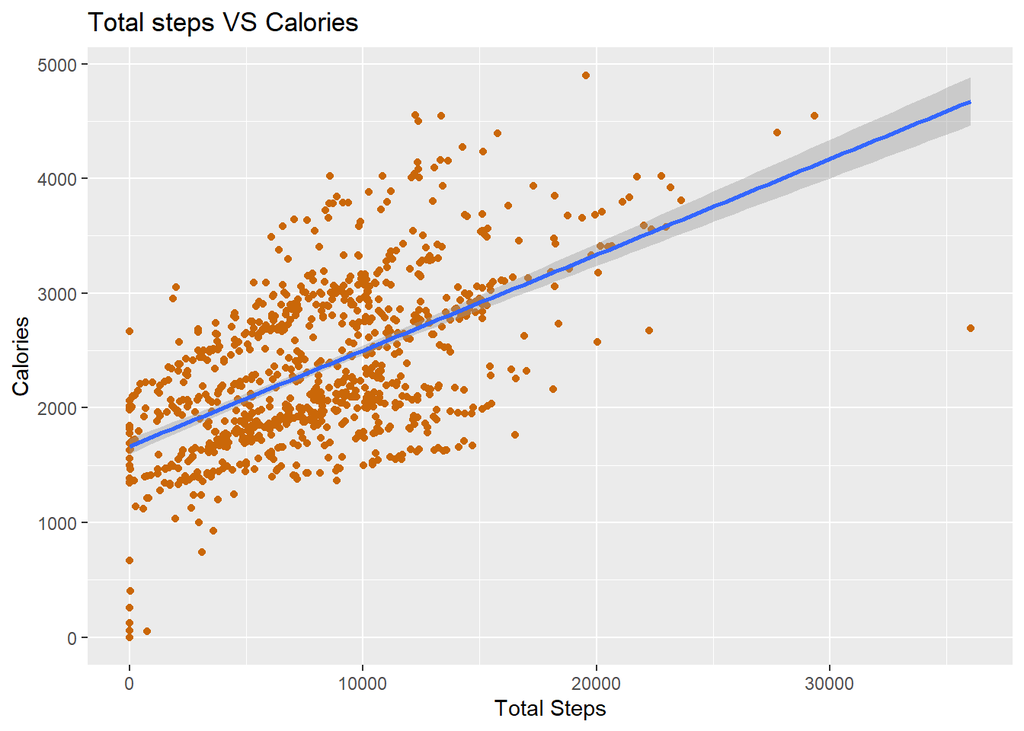

```r
ggplot(data=daily_activity, aes(x=TotalSteps, y = Calories))+
  geom_point(color="#ca6708") +
   labs(title="Total steps VS Calories", x="Total Steps", y="Calories") + stat_smooth(method=lm)
```

**in general the people who took the most total steps tended to burn the most calories however, there’s a large spread there clustered towards the lower amounts.**

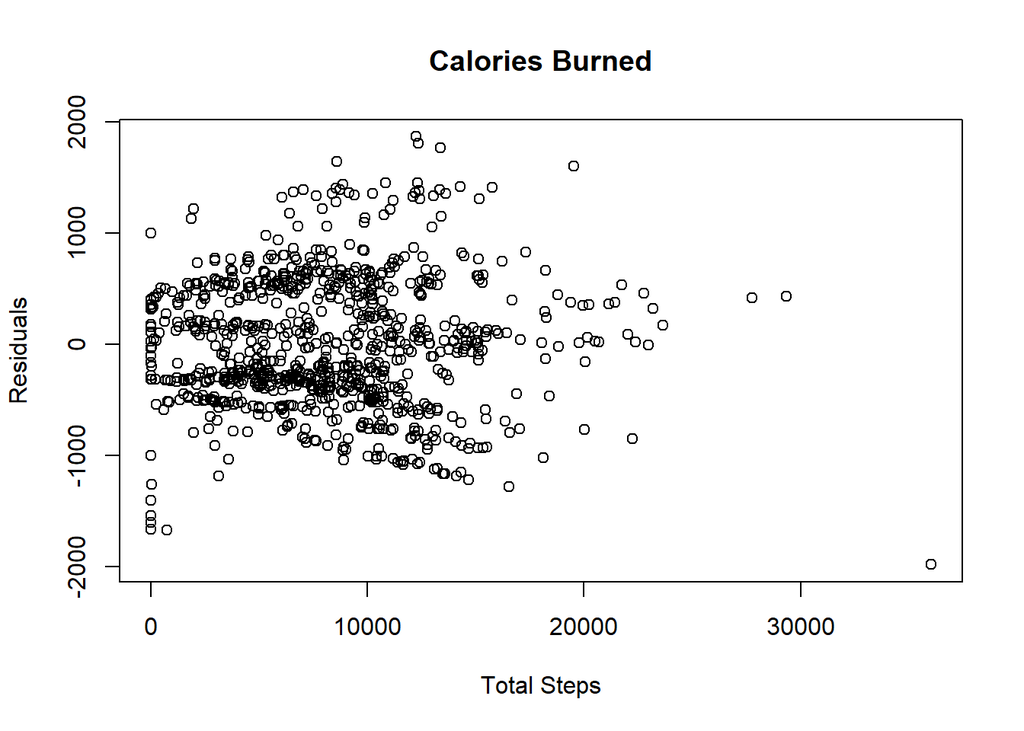

```r
calories.lm <- lm(Calories ~ TotalSteps, data = daily_activity)
calories.res <- resid(calories.lm)

plot(daily_activity$TotalSteps, calories.res, ylab="Residuals",xlab = "Total Steps", main = "Calories Burned", )
```

Now lets plot the density of the residuals

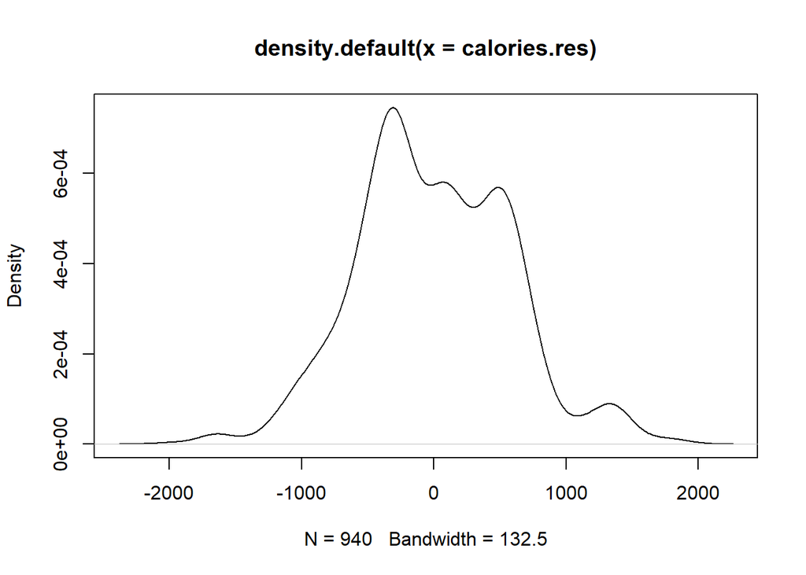

```r
plot(density(calories.res))
```

Checking for normality

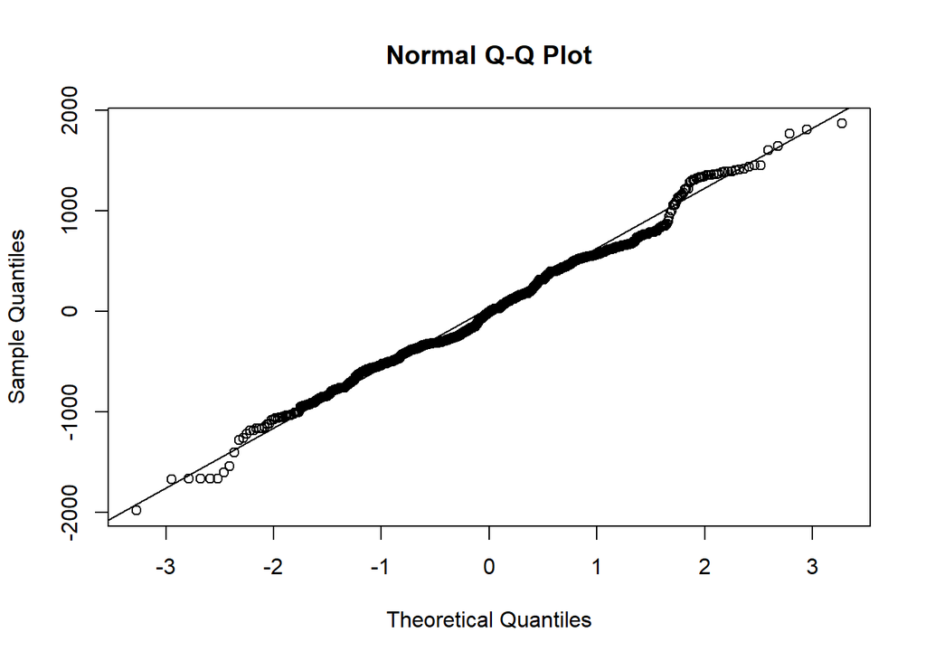

```r
qqnorm(calories.res)
qqline(calories.res)
```

- looks like the spread isn’t as far statistically as we though

#### A potential strategy

- In order to burn calories, you don’t have to do high-intensity work outs, you can just get out there and start walking,

### Sleep VS Time in Bed

1:1 trend from the amount of time slept and the total time someone spends in bed

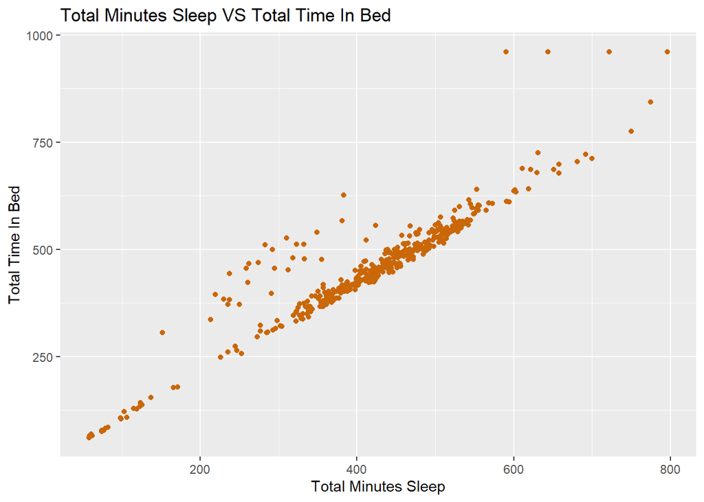

```r
ggplot(data=sleep_day, aes(x=TotalMinutesAsleep, y=TotalTimeInBed)) +
  geom_point(color="#ca6708") +
   labs(title="Total Minutes Sleep VS Total Time In Bed", x="Total Minutes Sleep", y="Total Time In Bed")
```

- there are some outliers.some data points that spent a lot of time in bed, but didn’t actually sleep, and then a small batch that slept a whole bunch and spent time in bed
- We could definitely market to consumers to monitor their time in bed with the watch against their sleep time.and could add some apps like night meditation or any sleeping aids voice books.

### sedentary minutes VS Sleep

Merging these two datasets together

```r
combined_sleep_day_data <- merge(sleep_day, daily_activity, by="Id")
head(combined_sleep_day_data)
```

```
##           Id              SleepDay TotalSleepRecords TotalMinutesAsleep
## 1 1503960366 4/12/2016 12:00:00 AM                 1                327
## 2 1503960366 4/12/2016 12:00:00 AM                 1                327
## 3 1503960366 4/12/2016 12:00:00 AM                 1                327
## 4 1503960366 4/12/2016 12:00:00 AM                 1                327
## 5 1503960366 4/12/2016 12:00:00 AM                 1                327
## 6 1503960366 4/12/2016 12:00:00 AM                 1                327
##   TotalTimeInBed ActivityDate TotalSteps TotalDistance TrackerDistance
## 1            346     5/7/2016      11992          7.71            7.71
## 2            346     5/6/2016      12159          8.03            8.03
## 3            346     5/1/2016      10602          6.81            6.81
## 4            346    4/30/2016      14673          9.25            9.25
## 5            346    4/12/2016      13162          8.50            8.50
## 6            346    4/13/2016      10735          6.97            6.97
##   LoggedActivitiesDistance VeryActiveDistance ModeratelyActiveDistance
```

[output cut: 20 more lines]

```r
n_distinct(combined_sleep_day_data$Id)
```

```
## [1] 24
```

- there are only 24 unique id’s in the combined dataset.
- since only 24 users actively used the sleep data.

### Sedentary Time vs Time In Bed

```r
sedentary.lm <- lm(SedentaryMinutes ~ TotalTimeInBed, data = combined_sleep_day_data)
sedentary.lm
```

```
##
## Call:
## lm(formula = SedentaryMinutes ~ TotalTimeInBed, data = combined_sleep_day_data)
##
## Coefficients:
##    (Intercept)  TotalTimeInBed
##       922.5632         -0.2688
```

now a pearson correlation coefficient

```r
cor(combined_sleep_day_data$TotalTimeInBed,combined_sleep_day_data$SedentaryMinutes, method = "pearson")
```

```
## [1] -0.1286386
```

### Very active minutes vs calories burned

[figure not shown]

```r
ggplot(data = combined_sleep_day_data, aes(x=VeryActiveMinutes, y=Calories)) +
  geom_point(color="#ca6708") + geom_smooth(method = 'loess', formula = y ~ x) +
  labs(title="Very Active Minutes vs. Calories Burned", x="VeryActiveMinutes", y="Calories Burned")
```

- A Moderate relationship for fairly active minutes.

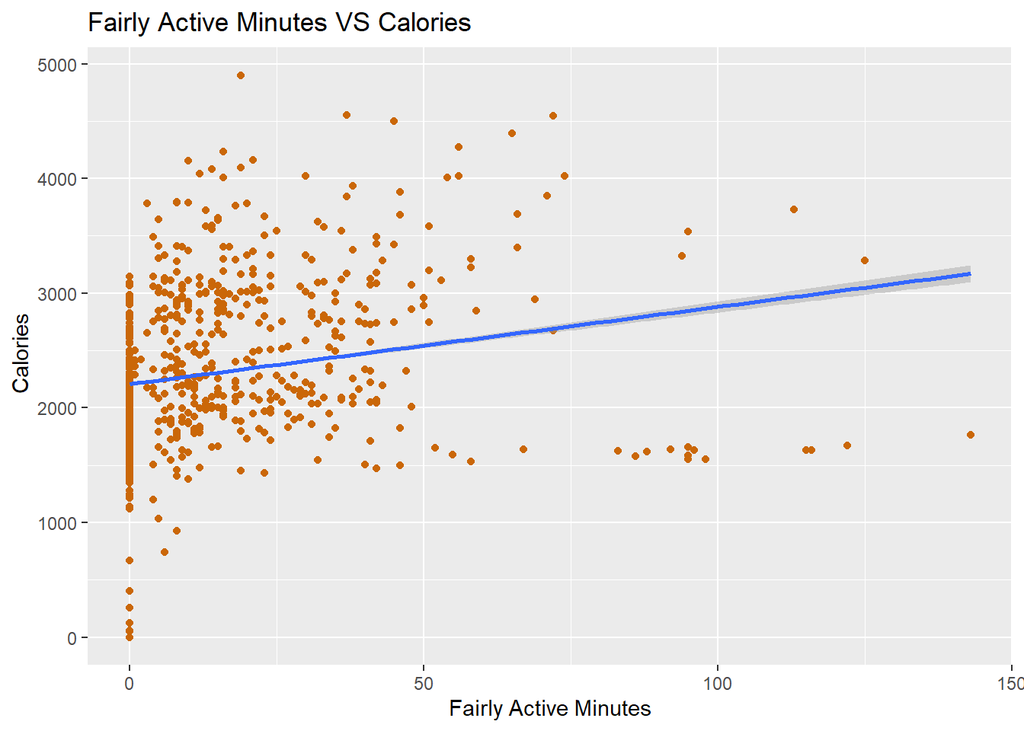

```r
ggplot(data = combined_sleep_day_data, aes(x=FairlyActiveMinutes, y=Calories)) +
   geom_point(color="#ca6708") +
   labs(title="Fairly Active Minutes VS Calories", x="Fairly Active Minutes", y=" Calories")+
  stat_smooth(method = lm)
```

```r
lm(Calories ~ FairlyActiveMinutes, data = combined_sleep_day_data)
```

```
##
## Call:
## lm(formula = Calories ~ FairlyActiveMinutes, data = combined_sleep_day_data)
##
## Coefficients:
##         (Intercept)  FairlyActiveMinutes
##            2205.987                6.739
```

## 6) Act

- we will be delivering our insights and providing recommendations based on our analysis.
- some trends has been identified and can be applied to Beallabeat.

## Takeaway And Recommendations :

1. **Adding some additional data capture techniques like hydration data, that puts Bellabeat way above the competition.**
2. **We should focus on marketing the fact that collecting data will help you (customer) set goals.**
3. **Marketing team can encourage users by educating and equipping them with knowledge about fitness benefits, suggest different types of exercise and calories intake and burnt rate information on the Bellabeat app. this provides a unique opportunity for individuals to change their behavior, become more physically active and increase their life expectancy.**
4. **adding features like notifications,competitions into the wearable’s ( eg. on weekends, Bellabeat app can rompt notification to encourage users to exercise)**
5. **Add some sleep aids tools like meditation or audio book and its can be monetized.**
6. **Make the device more comfortable on sleep and adding sleep tracking features.**
7. **We could market to consumers by telling them smart-devices could help them start their journey by measuring how much they’re already moving**.